# Estimating phenotypic selection differentials

Sandy Kawano

2016-06-16

### Install psa from GitHub

```r
require(devtools)
```

```r
#install_github("MorphoFun/psa", build_vignettes = TRUE)
library(psa)
library(ggplot2)
```

To see all of the vignettes that are available in `psa`, type `browseVignettes("psa")`.

### Loading the Male Bumpus data as an example

```r
data(BumpusMales)
```

### Check the structure of the data

```r
str(BumpusMales)
```

```
## 'data.frame':    87 obs. of  13 variables:
##  $ w             : num  1.71 1.71 1.71 1.71 1.71 ...
##  $ W             : int  1 1 1 1 1 1 1 1 1 1 ...
##  $ TotalLength_mm: int  154 160 155 154 156 161 157 159 158 158 ...
##  $ AlarExtent_mm : int  241 252 243 245 247 253 251 247 247 252 ...
##  $ Weight_g      : num  24.5 26.9 26.9 24.3 24.1 26.5 24.6 24.2 23.6 26.2 ...
##  $ SkullL_mm     : num  31.2 30.8 30.6 31.7 31.5 31.8 31.1 31.4 29.8 32 ...
##  $ HumerusL_mm   : num  17.4 18.7 18.6 18.8 18.2 ...
##  $ FemurL_mm     : num  17 18 17.9 17.5 17.9 ...
##  $ TibioTarL_mm  : num  26 30 29.2 29.1 28.7 ...
##  $ SkullW_mm     : num  14.9 15.3 15.3 14.8 14.6 ...
##  $ SternumL_mm   : num  21.1 21.4 21.5 21.3 20.9 ...
##  $ Sex           : Factor w/ 2 levels "0","1": 2 2 2 2 2 2 2 2 2 2 ...
##  $ AgeGroup      : int  1 1 1 1 1 1 1 1 1 1 ...
```

### Check the documentation to understand what each of the 13 columns represent

```r
?BumpusMales
```

### Define the parameters

#### Fitness will be represented by the relative fitness (w), which is the absolute fitness (W) of an individual divided by the mean absolute fitness for the group.

```r
w <- BumpusMales[,1]
```

#### The phenotypic traits are stored under z:

```r
z <- BumpusMales[,3:11]
```

#### Since Weight is a volume, and the other traits are linear measurements, we need to adjust for the dimensionality differences by taking the cube root of Weight_g. (Alternatively, one could cube all of the other phenotypic traits except Weight_g)

```r
z$Weight_g <- z$Weight_g^(1/3)
```

### Estimate phenotypic selection differentials

*Overview of estimating selection differentials*

| Parameter | Formula |
| --- | --- |
| linear selection differential ($S_i$) | $cov(w, \bar{z}$) |
| quadratic selection differential ($C_{i,i}$) | $cov(w, (z - \bar{z})^2$) |
| correlational selection differential ($C_{i,j}$) | $cov(w, (z_i - \bar{z_i})(z_j - \bar{z_j}$)) |

See Brodie et al. 1995 for a more detailed description.

#### Calculate the selection differentials

The phenotypic traits (z) will automatically be centered to a mean of zero and scaled to unit variance. The differentials() function outputs the linear and nonlinear selection differentials. The terms ending in “.Sq” are the quadratic selection differentials, and the interactions are the correlational selection differentials.

```r
# Look up the documentation for differentials
?differentials

# Estimate the differentials using only the covariance method
bm_dCov <- differentials(w, z, 1)

# Look up the documentation for differentials_bootstats for estimating the standard errors and confidence intervals, using the covariance method for estimating the selection differentials
?differentials_bootstats

set.seed(123)
bm_booted_dCov <- differentials_bootstats(w, z, method = 1)

# The standard errors can be easily extracted from $se
bm_booted_dCov$se
```

```
##  [1] 0.1042168 0.1318674 0.1098956 0.1299738 0.1249598 0.1261430 0.1269853
##  [8] 0.1291953 0.1239088 0.1429121 0.1667845 0.1672175 0.1889650 0.1871493
## [15] 0.1661274 0.1905353 0.1862803 0.1538824 0.1355226 0.1150074 0.1200143
## [22] 0.1418175 0.1423942 0.1405216 0.1292343 0.1047464 0.1314049 0.1432020
## [29] 0.1633147 0.1577523 0.1650040 0.1480480 0.1324577 0.1262453 0.1350611
## [36] 0.1359055 0.1368122 0.1274975 0.1234283 0.1491501 0.1440079 0.1548516
## [43] 0.1412952 0.1183042 0.1680533 0.1813942 0.1550478 0.1403208 0.1741378
## [50] 0.1409219 0.1291984 0.1449171 0.1352912 0.1023014
```

#### Are all methods to estimate selection differentials equivalent?

The short answer is: no. To illustrate this, we can use the psa::differentials function to compare how different methods to quantify selection differentials impact the results.

```r
# Compare the differentials using different methods
bm_all <- differentials(w, z, "all")

# Compare the standard errors of the differentials that were estimated with different methods
set.seed(123)
bm_booted_dBeforeAfter <- differentials_bootstats(w,z,method = 2)
bm_booted_dMatrix <- differentials_bootstats(w,z,method = 3)
bm_booted_dReg <- differentials_bootstats(w,z,method = 4)

bm_se_all <- data.frame(cbind(dCov = bm_booted_dCov$se, dBeforeAfter = bm_booted_dBeforeAfter$se, dMatrix = bm_booted_dMatrix$se, dReg = bm_booted_dReg$se), stringsAsFactors = FALSE)


# melt the results based on the method used to compute the estimates
library(reshape2)
melt_bm <- melt(t(bm_all), id = names(bm_all))
melt_bm_se <- melt(t(bm_se_all), id = names(bm_se_all))

limits <- aes(ymax = melt_bm$value + melt_bm_se$value, ymin = melt_bm$value - melt_bm_se$value)
```

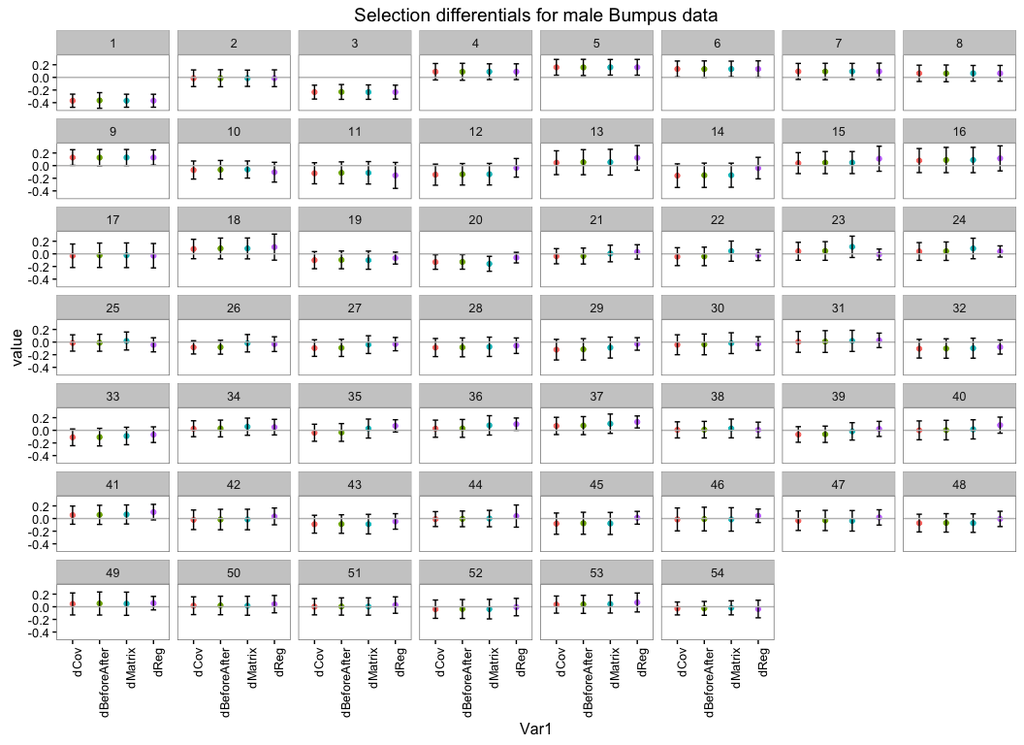

```r
# plot the data
# see docs.ggplot2.org/current/geom_point.html
ggplot(melt_bm, aes(Var1, value, fill = Var1)) +
  geom_point(aes(colour = factor(Var1))) +
  geom_errorbar(limits, width = 0.2) +
  # once I have the se's try:   geom_point(aes(colour = factor(Method), size = se)) +
  facet_wrap(~Var2) +
  geom_abline(intercept = 0, slope = 0, colour = "gray") +
  labs(title = "Selection differentials for male Bumpus data") +
  theme_bw() +
  theme(axis.text.x = element_text(angle = 90, hjust = 1)) +
  theme(legend.position = "none",
    panel.grid.major = element_blank(),
    panel.grid.minor = element_blank(),
    panel.background = element_blank(),
    axis.line = element_line(colour = "black")
    )
```

```r
# the function can also be run without normalizing the phenotypic traits by setting normalize = FALSE
differentials(w, z, "all", normalize = FALSE)
```

```
##             dCov dBeforeAfter       dMatrix         dReg
## 1  -0.3694482090 -0.365201678 -0.3694482090 -0.369448209
## 2  -0.0135955629 -0.013439292 -0.0135955629 -0.013595563
## 3  -0.2331200346 -0.230440494 -0.2331200346 -0.233120035
## 4   0.0897961209  0.088763982  0.0897961209  0.089796121
## 5   0.1597756323  0.157939131  0.1597756323  0.159775632
## 6   0.1330311154  0.131502022  0.1330311154  0.133031115
## 7   0.0942776554  0.093194004  0.0942776554  0.094277655
## 8   0.0643777446  0.063637771  0.0643777446  0.064377745
## 9   0.1283547160  0.126879374  0.1283547160  0.128354716
## 10 -0.0699714012 -0.064942058 -0.0618223445 -0.104218334
## 11 -0.1210564442 -0.113786041 -0.1137818161 -0.154948537
## 12 -0.1432745016 -0.137246416 -0.1360042867 -0.034827633
## 13  0.0457080018  0.054204556  0.0543888550  0.122953199
## 14 -0.1589423546 -0.152480773 -0.1518972892 -0.038887069
```

[output cut: 40 more lines]

Robertson (1966) and Price (1970, 1972) originally proposed that directional selection on individual phenotypic traits could be estimated by either the covariance or regression of relative fitness on the trait (Lande and Arnold 1983).

Similar results can be found for other datasets. Here is the humanNeonatal dataset from the gsg package, which has a much larger sample size than the BumpusMales dataset.

```r
require(gsg)
data(humanNeonatal)
str(humanNeonatal)
```

```
## 'data.frame':    7036 obs. of  3 variables:
##  $ nns : num  0 0 0 0 0 0 0 0 0 0 ...
##  $ bw  : num  0.455 0.455 0.455 2.5 0.455 ...
##  $ gest: num  155 165 165 170 180 180 180 185 185 185 ...
```

```r
# Creating a relative fitness (w) variable
humanNeonatal$w <- humanNeonatal$nns/mean(humanNeonatal$nns)

# Comparing the selection differentials
differentials(humanNeonatal$w, humanNeonatal[,2:3], "all")
```

```
##          dCov dBeforeAfter     dMatrix        dReg
## 1  0.06666627   0.06665680  0.06666627  0.06666627
## 2  0.06123139   0.06122269  0.06123139  0.06123139
## 3 -0.20569286  -0.20568717 -0.20568591 -0.08564454
## 4 -0.21596581  -0.21596010 -0.21595903 -0.05761114
## 5 -0.19189301  -0.19189138 -0.19222300 -0.04301346
```

Given that the original formulae to estimate linear and nonlinear selection differentials (e.g., Lande and Arnold 1983, Phillips and Arnold 1989) were based on the covariance method, it would likely be best to stick to that method. With data normalized to a mean of zero and unit variance: simple linear regressions can produce similar results as the covariance method for linear selection differentials, but are inconsistent for nonlinear selection differentials. With raw data: taking the phenotypic differences before and after selection can produce similar results as the covariance method for both linear and nonlinear selection differentials. For the humanNeonatal dataset, notice that the estimates were relatively consistent amongst the first three methods for both linear and nonlienar selection differentials; the regression method produced the most incongruent results.

**References**  
Brodie ED III, Moore AJ, Janzen FJ. 1995. Visualizing and quantifying natural selection. *TREE* 10(8): 313-318.  
Lande SJ, Arnold R. 1983. The measurement o fselection on correlated characters. *Evolution* 37(6): 1210-1226.  
Phillips PC, Arnold SJ. 1989. Visualizing multivariate selection. *Evolution* 43(6): 1209-1222. Price GR. 1970. Selection and covariance. *Nature* 227: 520-521.  
Price GR. 1972. Extension of covariance selection mathematics. *Annals of Human Genetics* 35: 485-490.  
Robertson A. 1966. A mathematical model of the culling process in dairy cattle. *Animal Production* 8: 93-108.